# Predictive Models for Popularity of Online News

Jasmine Wang & Ilana Feldman

10/31/2021

# Introduction

Due to the expansion of online businesses, people can almost do anything online. With the increasing amount of Internet usages, there has been a growing interest in online news as well since they allow for an easier and faster spread of information around the world. Hence, predicting the popularity of online news has become an interest for research purposes. Popularity of online news is frequently measured by the number of interactions in the social networks such as number of likes, comments and shares. Predicting such measures is important to news authors, advertisers and publishing organizations. Therefore, the study collected news articles published between January 7th, 2013 and January 7th, 2015 from different channels on Mashable which is one of the largest online news sites.

The study collected a total of 39,000 news articles from six data channel categories such as lifestyle, entertainment, business, social media, technology and world. In addition, the features contained in the articles were also measured to help predict the popularity of the news contents. Such features include digital media content (number of images or videos), earlier popularity of news referenced in the article; average number of shares of keywords, natural language features (title popularity or Latent Dirichlet Allocation topics) and many others. The study included 58 predictive attributes, 2 non-predictive attributes and 1 goal field which is the number of shares of the articles. The collected data was donated by the study to the [UCI Machine Learning repository](https://archive.ics.uci.edu/ml/datasets/online+news+popularity) where we downloaded the data.

Table 1 shows the list of variables we used in the analysis and their descriptions. The study shows after the best predictive model was selected using a test set, these variables that we are interested in are among the top ranked features according to their importance in the final predictive model using the entire data set. Thus, we are going to investigate their importance in predicting the number of shares using the predictive models we propose.

The purpose of the analyses is to compare different predictive models and choose the best model in predicting the popularity of online news regarding their features in different channel categories. The methods implemented in prediction of shares are linear regression models using different predictors, a random forest model and a boosted tree model. More details are in the *Candidate Models* section.

The optimal model is chosen based on the majority score of the three metrics, root Mean Squared Error, Mean Absolute Error, and R-Squared values when fitting the candidate models on the test set. If each of the metrics picks a different model or the majority score is a tie, the one with the lowest RMSE will be chosen.

Table 1. Attributes used in the analyses for prediction of online news popularity

| Index | Attribute | Attribute Information | Type |
| --- | --- | --- | --- |
| 1 | `shares` (target) | Number of shares | number |
| 2 | `kw_avg_avg` | Average keyword (average shares) | number |
| 3 | `LDA_02` | Closeness of current article to a LDA Topic 2 | ratio |
| 4.1 | `weekday_is_monday` | Was the article published on a Monday? | boolean |
| 4.2 | `weekday_is_tuesday` | Was the article published on a Tuesday? | boolean |
| 4.3 | `weekday_is_wednesday` | Was the article published on a Wednesday? | boolean |
| 4.4 | `weekday_is_thursday` | Was the article published on a Thursday? | boolean |
| 4.5 | `weekday_is_friday` | Was the article published on a Friday? | boolean |
| 4.6 | `weekday_is_saturday` | Was the article published on a Saturday? | boolean |
| 4.7 | `weekday_is_sunday` | Was the article published on a Sunday? | boolean |
| 5 | `self_reference_avg_sharess` | Avg. shares of popular news referenced in the articles | number |
| 6 | `average_token_length` | Average length of the words in the content | number |
| 7 | `n_tokens_content` | Number of words in the content | number |
| 8 | `n_tokens_title` | Number of words in the title | number |
| 9 | `global_subjectivity` | Text subjectivity | ratio |
| 10 | `num_imgs` | Number of images | number |

```r
library(rmarkdown)
library(tidyverse)
library(knitr)
library(caret)
library(corrplot)
library(ggplot2)
library(gbm)
library(vip)

allnews <- read_csv("../_Data/OnlineNewsPopularity.csv", col_names = TRUE)

########KNIT with parameters!!!!!!!!!channels is in quotes!!!!Need to use it with quotes!!!!!!!!!!!!!!!!!!!!!!!!
channels <- paste0("data_channel_is_", params$channel)
subnews <- allnews[allnews[, channels] == 1, ]

news <- subnews %>% select(
  -data_channel_is_lifestyle, -data_channel_is_entertainment, -data_channel_is_bus, -data_channel_is_socmed,
  -data_channel_is_tech, -data_channel_is_world, -url, -timedelta)
#################!!!!!!!!!!!!!!!!!!!!!!!!!!!!!!!!!!!!!!!!!!!!!!!!!!!!!!!!!

diffday <- news %>% mutate(log.shares = log(shares),
                           class_shares = if_else(shares < 1400, 0, 1),
                           dayweek = if_else(weekday_is_monday == 1, 1,
                                    if_else(weekday_is_tuesday == 1, 2,
                                    if_else(weekday_is_wednesday == 1, 3,
                                    if_else(weekday_is_thursday == 1, 4,
                                    if_else(weekday_is_friday == 1, 5,
                                    if_else(weekday_is_saturday == 1, 6, 7))))))
                           )

sel_data <- diffday %>% select(class_shares, shares, log.shares, dayweek,
                               kw_avg_avg,
                               LDA_00, LDA_01, LDA_02, LDA_03, LDA_04,
                               weekday_is_monday, weekday_is_tuesday, weekday_is_wednesday,
                               weekday_is_thursday, weekday_is_friday, weekday_is_saturday, weekday_is_sunday,
                               self_reference_avg_sharess,
                               average_token_length,
                               n_tokens_content, n_tokens_title, global_subjectivity,
                               num_imgs)

set.seed(388588)
sharesIndex <- createDataPartition(sel_data$shares, p = 0.7, list = FALSE)
train <- sel_data[sharesIndex, ]
test <- sel_data[-sharesIndex, ]
train
```

```
## # A tibble: 1,472 x 23
##    class_shares shares log.shares dayweek kw_avg_avg LDA_00 LDA_01 LDA_02 LDA_03
##           <dbl>  <dbl>      <dbl>   <dbl>      <dbl>  <dbl>  <dbl>  <dbl>  <dbl>
##  1            0    556       6.32       1         0  0.0201 0.115  0.0200 0.0200
##  2            1   1900       7.55       1         0  0.0286 0.0286 0.0286 0.0287
##  3            1   5700       8.65       1         0  0.437  0.200  0.0335 0.0334
##  4            0    462       6.14       1         0  0.0200 0.0200 0.0200 0.0200
##  5            1   3600       8.19       1         0  0.211  0.0255 0.0251 0.0251
##  6            0    343       5.84       1         0  0.0201 0.0206 0.0205 0.121
##  7            0    507       6.23       1         0  0.0250 0.160  0.0250 0.0250
##  8            0    552       6.31       1         0  0.207  0.146  0.276  0.0251
##  9            0   1200       7.09       2       885. 0.0202 0.133  0.120  0.0201
## 10            1   1900       7.55       3      1207. 0.0335 0.217  0.0334 0.0335
## # ... with 1,462 more rows, and 14 more variables: LDA_04 <dbl>,
## #   weekday_is_monday <dbl>, weekday_is_tuesday <dbl>,
## #   weekday_is_wednesday <dbl>, weekday_is_thursday <dbl>,
## #   weekday_is_friday <dbl>, weekday_is_saturday <dbl>,
## #   weekday_is_sunday <dbl>, self_reference_avg_sharess <dbl>,
## #   average_token_length <dbl>, n_tokens_content <dbl>, n_tokens_title <dbl>,
## #   global_subjectivity <dbl>, num_imgs <dbl>
```

```r
train1 <- train %>% select(-class_shares, -shares,
                           -weekday_is_monday, -weekday_is_tuesday, -weekday_is_wednesday, -weekday_is_thursday,
                           -weekday_is_friday, -weekday_is_saturday, -weekday_is_sunday, -LDA_00, -LDA_01, -LDA_03, -LDA_04)

test1 <- test %>% select(-class_shares, -shares,
                         -weekday_is_monday, -weekday_is_tuesday, -weekday_is_wednesday, -weekday_is_thursday,
                         -weekday_is_friday, -weekday_is_saturday, -weekday_is_sunday, -LDA_00, -LDA_01, -LDA_03, -LDA_04)
```

# Data

When a subset of data is selected for the lifestyle channel articles which contain 2099 articles, the subset of data is then split into a training set (70% of the subset data) and a test set (30% of the subset data) based on the target variable, the number of shares. There are 1472 articles in the training set and 627 observations in the test set regarding the lifestyle channel. The `createDataPartition` function from the `caret` package is used to split the data into training and test sets. We set a seed so that the analyses we implemented are reproducible.

The data donated by the study contains a “day of the week” categorical variable but in a boolean format (dummy variable) asking if the article was published on a day of a week for all seven days which is also shown in Table 1. Thus, we created a new variable called `dayweek` with seven levels to combine these dummy variables for the linear regression models. When `dayweek` = 1, the article was published on a Monday, when `dayweek` = 2, the article was published on a Tuesday, …, and when `dayweek` = 7, the article was published on a Sunday.

However, these `dayweek` related variables for each day of the week in boolean format are needed when we run the ensemble models. In addition, we classified the articles based on their number of shares into two categories, a “popular” group when their number of shares is more than 1,400 and an “unpopular” group when their number of shares is less than 1,400. Note that, when we dichotomize a continuous variable into different groups, we lose information about that variable. We hope to see some patterns in different categories of shares although what we discover may not reflect on what the data really presents because we did not use the “complete version” of the information within the data. This is purely for data exploratory analysis purpose in the next section.

# Exploratory Data Analysis

## Numerical Summaries

Table 2 shows the popularity of the news articles on different days of the week. We classified the number of shares greater than 1400 in a day as “popular” and the number of shares less than 1400 in a day as “unpopular”. We can see the number of articles from the lifestyle channel classified into “popular” group or “unpopular” group on different days of the week from January 7th, 2013 to January 7th, 2015 when the articles were published and retrieved by the study. Note, this table may not reflect on the information contained in the data due to dichotomizing the data.

Table 3 shows the average shares of the articles on different days of the week. We can compare and determine which day of the week has the most average number of shares for the lifestyle channel. Here, we can see a potential problem for our analysis later. Median shares are all very different from the average shares on any day of the week. Recall that median is a robust measure for center. It is robust to outliers in the data. On the contrary, mean is also a measure of center but it is not robust to outliers. Mean measure can be influenced by potential outliers.

In addition, Table 3 also shows the standard deviation of shares is huge for any day of the week. They are potentially larger than the average shares. This tells us the variance of shares for any day is huge. We know a common variance stabilizing transformation to deal with increasing variance of the response variable, that is, the log-transformation, which could help us on this matter. Therefore, Table 3 again shows after the log-transformation of shares, the mean values are similar to their corresponding median values, and their standard deviations are much smaller than before relatively speaking.

Table 4 shows the numerical summaries of *average keywords* from lifestyle channel in mashable.com on different days of the week. This table indicates the number of times *average keywords* shown in the articles regarding the average number of shares, and the table is showing the average number of those *average keywords* calculated for each day of the week so that we can compare to see which day of the week, the *average keywords* showed up the most or the worst according to the average of shares in the lifestyle channel.

Table 5 shows the numerical summaries of average shares of referenced articles in mashable.com on different days of the week. We calculated the average number of shares of those articles that contained the earlier popularity of news referenced for each day of the week so that we can compare which day has the most or the worst average number of shares when there were earlier popularity of news referenced in the lifestylearticles.

Table 6 checks the numerical summaries of the `global_subjectivity` variable between popular and unpopular articles, to see if there’s any difference or a higher variation in subjectivity in popular articles. Text subjectivity is a value between 0 and 1, so there isn’t any need for transformation.

Table 7 checks the numerical summaries of the image count per article on different days of the week, to see if there is a noticeable difference in image count on weekends versus weekdays across all channels, or only certain ones. Much like in table 2, the mean is smaller than the standard deviation for most of the days of the week, and the solution isn’t as straightforward, since many of the articles don’t have any images at all. I’ll additionally include a log transformation of `images + 1` to account for this.

```r
# contingency table
edadata <- train
edadata$class.shares <- cut(edadata$class_shares, 2, c("Unpopular","Popular"))
edadata$day.week <- cut(edadata$dayweek, 7, c("Monday", "Tuesday", "Wednesday", "Thursday", "Friday", "Saturday", "Sunday"))
table(edadata$class.shares, edadata$day.week) %>% kable(caption = "Table 2. Popularity on Day of the Week")
```

Table 2. Popularity on Day of the Week

|  | Monday | Tuesday | Wednesday | Thursday | Friday | Saturday | Sunday |
| --- | --- | --- | --- | --- | --- | --- | --- |
| Unpopular | 91 | 107 | 121 | 99 | 91 | 19 | 44 |
| Popular | 132 | 128 | 152 | 155 | 122 | 95 | 116 |

```r
edadata %>% group_by(day.week) %>% summarise(
  Avg.shares = mean(shares), Sd.shares = sd(shares), Median.shares = median(shares),
  Avg.logshares = mean(log.shares), Sd.logshares = sd(log.shares), Median.logshares = median(log.shares)) %>%
  kable(digits = 4, caption = "Table 3. Average Shares vs. Average Log(shares) on Day of the Week")
```

Table 3. Average Shares vs. Average Log(shares) on Day of the Week

| day.week | Avg.shares | Sd.shares | Median.shares | Avg.logshares | Sd.logshares | Median.logshares |
| --- | --- | --- | --- | --- | --- | --- |
| Monday | 3486.045 | 5318.719 | 1600 | 7.5882 | 0.9883 | 7.3778 |
| Tuesday | 4168.881 | 14793.301 | 1400 | 7.5302 | 0.9636 | 7.2442 |
| Wednesday | 3399.795 | 6374.130 | 1600 | 7.5289 | 0.9706 | 7.3778 |
| Thursday | 3669.768 | 6002.006 | 1600 | 7.6033 | 0.9941 | 7.3778 |
| Friday | 2939.681 | 4380.366 | 1500 | 7.5090 | 0.8830 | 7.3132 |
| Saturday | 4073.597 | 5418.537 | 2300 | 7.8972 | 0.8131 | 7.7407 |
| Sunday | 3517.994 | 4285.079 | 2000 | 7.7887 | 0.7859 | 7.6009 |

```r
edadata %>% group_by(day.week) %>% summarise(
  Avg.keyword = mean(kw_avg_avg), Sd.keyword = sd(kw_avg_avg), Median.keyword = median(kw_avg_avg),
  IQR.keyword = IQR(kw_avg_avg)) %>%
  kable(digits = 4, caption = "Table 4. Summary of Average Keywords on Day of the Week")
```

Table 4. Summary of Average Keywords on Day of the Week

| day.week | Avg.keyword | Sd.keyword | Median.keyword | IQR.keyword |
| --- | --- | --- | --- | --- |
| Monday | 3246.340 | 1348.691 | 3185.484 | 1134.762 |
| Tuesday | 3264.005 | 1032.268 | 3149.765 | 1135.409 |
| Wednesday | 3451.520 | 1800.231 | 3250.528 | 1292.849 |
| Thursday | 3311.112 | 1136.251 | 3233.834 | 1295.447 |
| Friday | 3196.760 | 1066.331 | 2996.297 | 1218.999 |
| Saturday | 3737.214 | 1076.623 | 3546.271 | 1438.096 |
| Sunday | 3817.900 | 1333.473 | 3752.708 | 1605.025 |

```r
edadata %>% group_by(day.week) %>% summarise(
  Avg.reference = mean(self_reference_avg_sharess), Sd.reference = sd(self_reference_avg_sharess),
  Median.reference = median(self_reference_avg_sharess), IQR.reference = IQR(self_reference_avg_sharess)) %>%
  kable(digits = 4, caption = "Table 5. Summary of Average shares of referenced articles in Mashable on Day of the Week")
```

Table 5. Summary of Average shares of referenced articles in Mashable on Day of the Week

| day.week | Avg.reference | Sd.reference | Median.reference | IQR.reference |
| --- | --- | --- | --- | --- |
| Monday | 6696.825 | 10535.357 | 3000 | 5300.0 |
| Tuesday | 5168.337 | 8723.726 | 2520 | 4295.2 |
| Wednesday | 7360.335 | 27000.613 | 2200 | 6200.0 |
| Thursday | 5844.472 | 13768.595 | 2475 | 5830.0 |
| Friday | 5673.178 | 12087.230 | 2100 | 4320.0 |
| Saturday | 5377.458 | 7985.266 | 2500 | 4787.5 |
| Sunday | 6853.131 | 20490.799 | 2350 | 3425.0 |

```r
edadata %>% group_by(class.shares) %>% summarize(
  Avg.subjectivity = mean(global_subjectivity), Sd.subjectivity = sd(global_subjectivity),
  Median.subjectivity = median(global_subjectivity)) %>%
  kable(digits = 4, caption = "Table 6. Comparing Global Subjectivity between Popular and Unpopular Articles")
```

Table 6. Comparing Global Subjectivity between Popular and Unpopular Articles

| class.shares | Avg.subjectivity | Sd.subjectivity | Median.subjectivity |
| --- | --- | --- | --- |
| Unpopular | 0.4726 | 0.0853 | 0.4774 |
| Popular | 0.4744 | 0.0983 | 0.4769 |

```r
edadata %>% group_by(day.week) %>% summarize(
  Avg.images = mean(num_imgs), Sd.images = sd(num_imgs), Median.images = median(num_imgs), Avg.log.images = mean(log(num_imgs + 1)), Sd.log.images = sd(log(num_imgs + 1)), Median.log.images = median(log(num_imgs + 1))) %>%
  kable(digits = 4, caption = "Table 7. Comparing Image Counts by the Day of the Week")
```

Table 7. Comparing Image Counts by the Day of the Week

| day.week | Avg.images | Sd.images | Median.images | Avg.log.images | Sd.log.images | Median.log.images |
| --- | --- | --- | --- | --- | --- | --- |
| Monday | 4.4709 | 5.8961 | 1.0 | 1.2323 | 0.9277 | 0.6931 |
| Tuesday | 4.0298 | 6.1153 | 1.0 | 1.1297 | 0.9070 | 0.6931 |
| Wednesday | 4.8388 | 8.9986 | 1.0 | 1.2006 | 0.9770 | 0.6931 |
| Thursday | 4.1063 | 6.6595 | 1.0 | 1.1295 | 0.9133 | 0.6931 |
| Friday | 4.3005 | 9.0238 | 1.0 | 1.1406 | 0.9025 | 0.6931 |
| Saturday | 7.3947 | 7.8138 | 4.5 | 1.6343 | 1.0611 | 1.7006 |
| Sunday | 7.4125 | 7.2271 | 6.0 | 1.6791 | 1.0422 | 1.9459 |

## Visualizations

Graphical presentation is a great tool used to visualize the relationships between the predictors and the number of shares (or log number of shares). Below we will see some plots that tell us stories between those variables.

### Correlation Plot

Figure 1 shows the linear relationship between the variables, both the response and the predictors, which will be used in the regression models as well as the ensemble models for predicting the number of shares. Notice that there may be potential collinearity among the predictor variables. The correlation ranges between -1 and 1, with the value equals 0 means that there is no linear relationship between the two variables. The closer the correlation measures towards 1, the stronger the positive linear correlation/relationship there is between the two variables. Vice verse, the close the correlation measures towards -1, the stronger the negative linear correlation/relationship there is between the two variables.

The correlation measures the “linear” relationships between the variables. If the relationships between the variables are not linear, then correlation measures cannot capture them, for instance, a quadratic relationship. Scatterplots between the variables may be easier to spot those non-linear relationships between the variables which we will show in the following section.

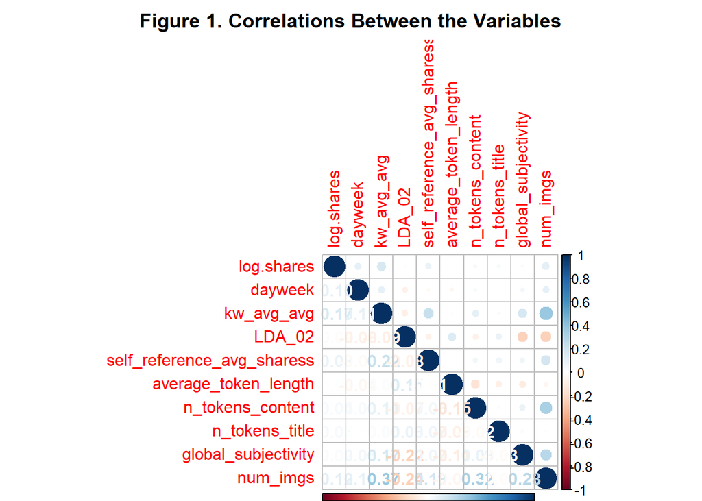

```r
correlation <- cor(train1, method="spearman")

corrplot(correlation, type = "upper", tl.pos = "lt",
         title="Figure 1. Correlations Between the Variables",
         mar = c(0, 0, 2, 0))
corrplot(correlation, type = "lower", method = "number", add = TRUE, diag = FALSE, tl.pos = "n")
```

### Boxplot

Figure 2 shows the number of shares across different days of the week. Here, due to the huge number of large-valued outliers, I capped the number of shares to 8,000 so that we can see the medians and the interquartile ranges clearly for different days of the week.

This is a boxplot with the days of the week on the x-axis and the number of shares on the y-axis. We can inspect the trend of shares to see if the shares are higher on a Monday, a Friday or a Sunday for the lifestyle articles.

Figure 2 coincides with the findings in Table 3 that the variance of shares is huge across days of the week, and the mean values of shares across different days are driven by larged-valued outliers. Therefore, those mean values of shares are not close to the median values of shares for each day of the week.

Figure 3 is a boxplot that compares the word count of the content of each article, grouped by the day of the week and additionally colored by its popularity. Similarly to before, for ease of viewing, the word count is capped at 2,000 since a small number of articles have a much larger word count in some cases. This has the capacity to indicate behavior regarding article length on different days of the week, article popularity based on length, or a cross-section of the two, where articles of some length may be more or less popular on some days of the week than others.

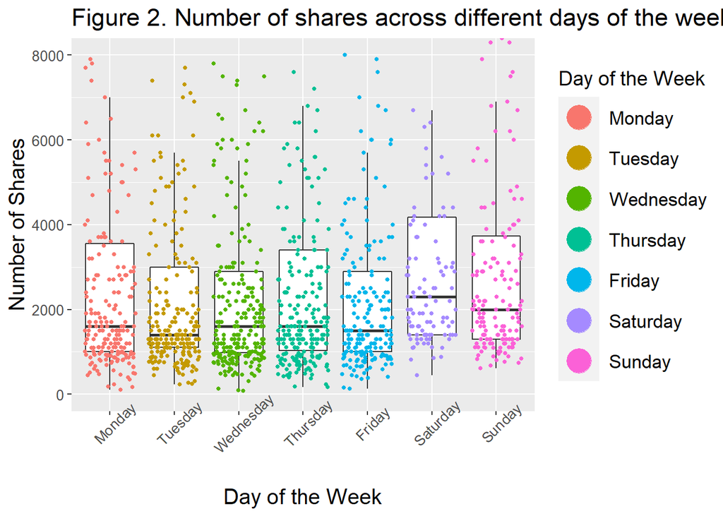

```r
ggplot(data = edadata, aes(x = day.week, y = shares)) +
  geom_boxplot(fill = "white", outlier.shape = NA) +
  coord_cartesian(ylim=c(0, 8000)) +
  geom_jitter(aes(color = day.week), size = 1) +
  guides(color = guide_legend(override.aes = list(size = 8))) +
  labs(x = "Day of the Week", y = "Number of Shares",
       title = "Figure 2. Number of shares across different days of the week") +
  scale_color_discrete(name = "Day of the Week") +
  theme(axis.text.x = element_text(angle = 45, size = 10),
        axis.text.y = element_text(size = 10),
        axis.title.x = element_text(size = 15),
        axis.title.y = element_text(size = 15),
        legend.key.size = unit(1, 'cm'),
        legend.text = element_text(size = 13),
        title = element_text(size = 14))
```

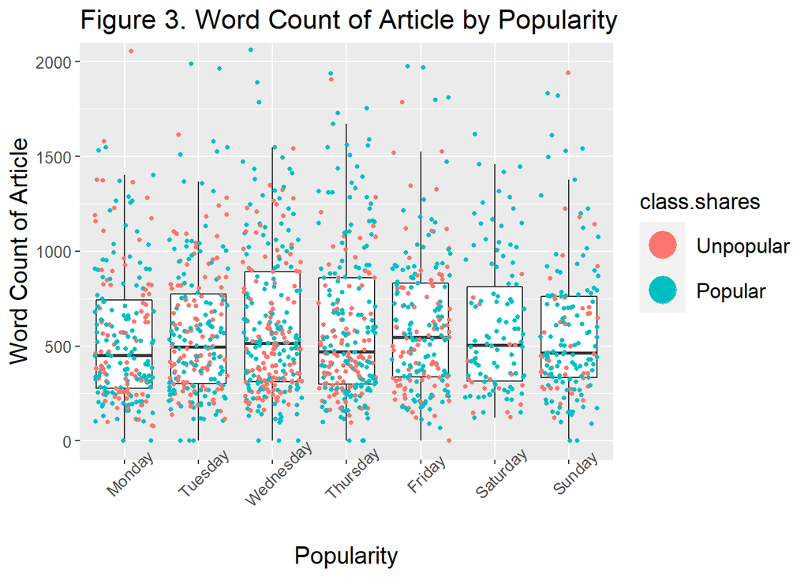

```r
ggplot(data = edadata, aes(x = day.week, y = n_tokens_content)) +
  geom_boxplot(fill = "white", outlier.shape = NA) +
  coord_cartesian(ylim=c(0, 2000)) +
  geom_jitter(aes(color = class.shares), size = 1) +
  guides(color = guide_legend(override.aes = list(size = 8))) +
  labs(x = "Popularity", y = "Word Count of Article",
       title = "Figure 3. Word Count of Article by Popularity") +
  theme(axis.text.x = element_text(angle = 45, size = 10),
        axis.text.y = element_text(size = 10),
        axis.title.x = element_text(size = 15),
        axis.title.y = element_text(size = 15),
        legend.key.size = unit(1, 'cm'),
        legend.text = element_text(size = 13),
        title = element_text(size = 14))
```

### Barplot

Figure 4 shows the popularity of the news articles in relations to their closeness to a top LDA topic for the lifestyle channel on any day of the week. The Latent Dirichlet Allocation (LDA) is an algorithm applied to the Mashable texts of the articles in order to identify the five top relevant topics and then measure the closeness of the current articles to each topic, and there are five topics categories. Thus, each article published on Mashable was measured for each of the topic categories. Together, those LDA measures in ratios are added to 1 for each article. Thus, these LDA topics variables are highly correlated with one another.

We calculated the mean ratios of these LDA topics variables for the specific day of the week. These mean ratios are further classified into a “popular” group and an “unpopular” group according to their number of shares (> 1400 or < 1400) which is shown in Figure 4 barplot. Note, the `position = "stack"` not `position = "fill"` in the `geom_bar` function.

Some mean ratios of a LDA topic do not seem to vary over the days of a week while other mean ratios of the LDA topics vary across different days of the week. Recall, when we dichotomize a continuous variable into different groups, we lose information about that variable. Here, I just want to show you whether or not the mean ratios of a LDA topic differ across time for different categories of shares.

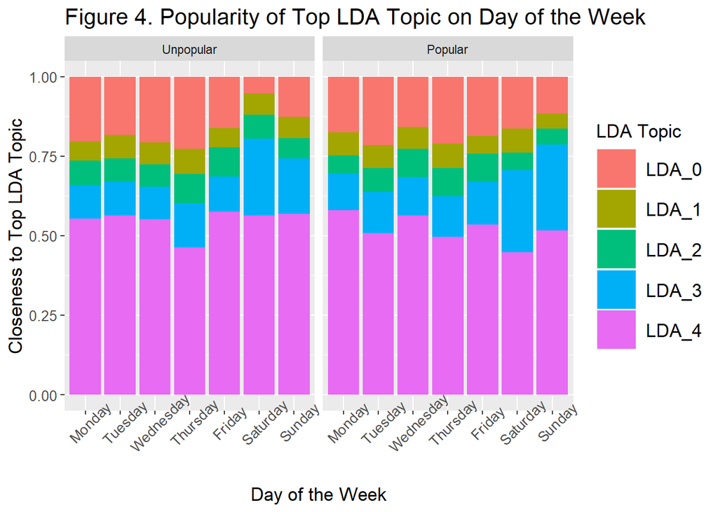

```r
b.plot1 <- edadata %>% group_by(day.week, class.shares) %>%
  summarise(LDA_0=mean(LDA_00), LDA_1=mean(LDA_01), LDA_2=mean(LDA_02), LDA_3=mean(LDA_03), LDA_4=mean(LDA_04))

b.plot2 <- b.plot1 %>% pivot_longer(cols = 3:7, names_to = "LDA.Topic", values_to = "avg.LDA")

ggplot(data = b.plot2, aes(x = day.week, y = avg.LDA, fill = LDA.Topic)) +
  geom_bar(stat = "identity", position = "stack") +
  labs(x = "Day of the Week", y = "Closeness to Top LDA Topic",
       title = "Figure 4. Popularity of Top LDA Topic on Day of the Week") +
  scale_fill_discrete(name = "LDA Topic") +
  theme(axis.text.x = element_text(angle = 45, size = 10),
        axis.text.y = element_text(size = 10),
        axis.title.x = element_text(size = 13),
        axis.title.y = element_text(size = 13),
        legend.key.size = unit(1, 'cm'),
        legend.text = element_text(size = 13),
        title = element_text(size = 13)) +
  facet_wrap(~ class.shares)
```

### Line Plot

Figure 5 is a line plot that shows the same measurements as in Figure 4 that we can see the patterns of the mean ratios of a LDA topic vary or not vary across time in different popularity groups more clearly. Again, some mean ratios of LDA topics do not seem to vary across time when the corresponding lines are flattened while other mean ratios of LDA topics vary across time when their lines are fluctuating. The patterns observed in the “popular” group may not reflect on the same trend in the “unpopular” group for articles in the lifestyle channel.

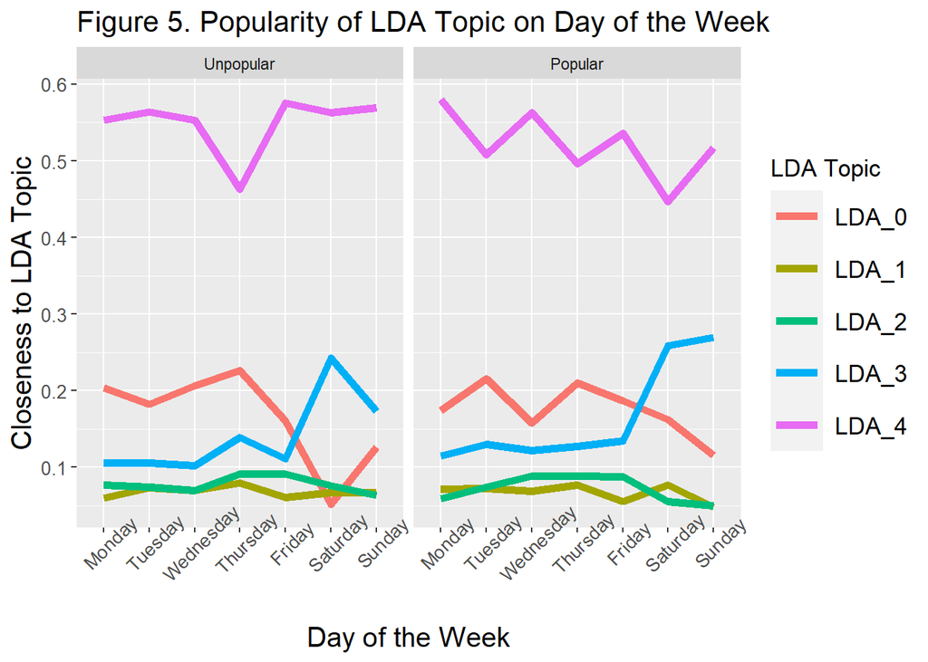

```r
l.plot1 <- edadata %>% group_by(day.week, class.shares) %>%
  summarise(LDA_0=mean(LDA_00), LDA_1=mean(LDA_01), LDA_2=mean(LDA_02), LDA_3=mean(LDA_03), LDA_4=mean(LDA_04))

l.plot2 <- l.plot1 %>% pivot_longer(cols = 3:7, names_to = "LDA.Topic", values_to = "avg.LDA")

ggplot(data = l.plot2, aes(x = day.week, y = avg.LDA, group = LDA.Topic)) +
  geom_line(aes(color = LDA.Topic), lwd = 2) +
  labs(x = "Day of the Week", y = "Closeness to LDA Topic",
       title = "Figure 5. Popularity of LDA Topic on Day of the Week") +
  scale_color_discrete(name = "LDA Topic") +
  theme(axis.text.x = element_text(angle = 45, size = 10),
        axis.text.y = element_text(size = 10),
        axis.title.x = element_text(size = 15),
        axis.title.y = element_text(size = 15),
        legend.key.size = unit(1, 'cm'),
        legend.text = element_text(size = 13),
        title = element_text(size = 13)) +
  facet_wrap(~ class.shares)
```

### Scatterplots

Figure 6 shows the relationship between the average keyword and log-transformed shares for articles in the lifestyle channel across different days of the week. In the news popularity study, it showed average keyword was ranked top one predictor in variable importance in the optimal predictive model (random forest) they selected that produced the highest accuracy in prediction of popularity online articles. Therefore, we are interested to see how average keyword is related with log shares. The different colored linear regression lines indicate different days of the week.

If the points display an upward trend, it indicates a positive relationship between the average keyword and log-shares. With an increasing log number of shares, the number of average keywords also increases, meaning people tend to share the article more when they see more of those average keywords in the article. On the contrary, if the points are in a downward trend, it indicates a negative relationship between the average keyword and log-shares. With an decreasing log number of shares, the number of average keywords decreases as well. People tend to share the articles less when they see less of these average keywords in the articles from the lifestyle channel.

Figure 7 is similar, except it compares the log-transformed number of shares to the log-transformed images in the article. As noted previously, both of these variables do not behave properly in a linear model due to the existence of extreme outliers in the data. Here, a negative correlation will indicate that shares sharply decreased for articles containing more images, and a positive correlation will indicate that shares sharply increased for articles containing more images.

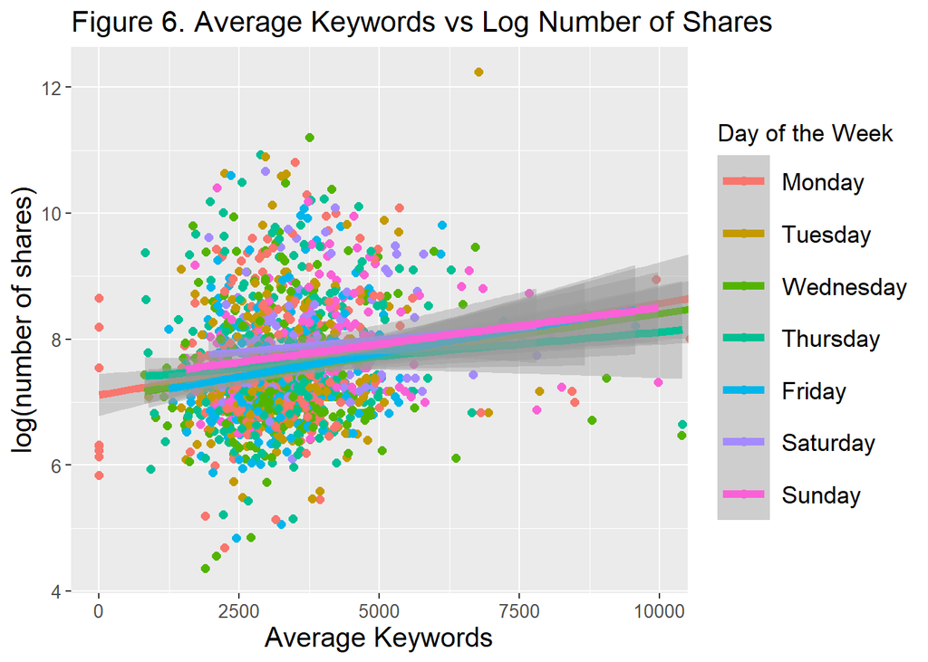

```r
ggplot(data = edadata, aes(x = kw_avg_avg, y = log.shares, color = day.week)) +
  geom_point(size = 2) + #aes(shape = class.shares)
  scale_color_discrete(name = "Day of the Week") +
  coord_cartesian(xlim=c(0, 10000)) +
  geom_smooth(method = "lm", lwd = 2) +
  labs(x = "Average Keywords", y = "log(number of shares)",
       title = "Figure 6. Average Keywords vs Log Number of Shares") +
  theme(axis.text.x = element_text(size = 10),
        axis.text.y = element_text(size = 10),
        axis.title.x = element_text(size = 15),
        axis.title.y = element_text(size = 15),
        legend.key.size = unit(1, 'cm'),
        legend.text = element_text(size = 13),
        title = element_text(size = 13))
```

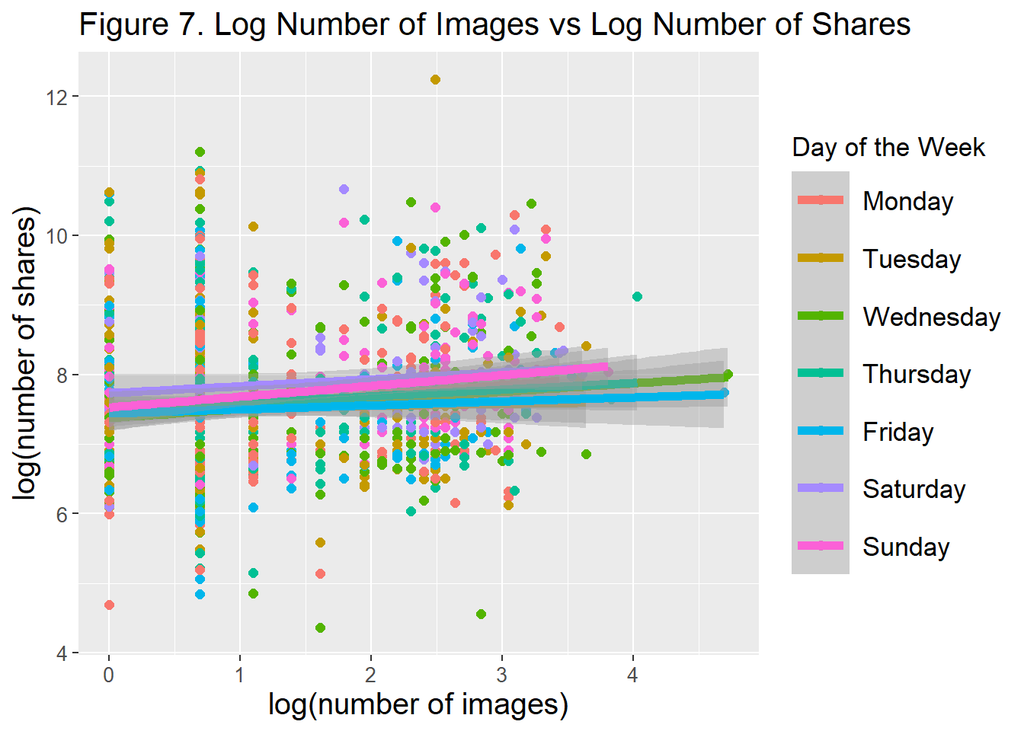

```r
ggplot(data = edadata, aes(x = log(num_imgs + 1), y = log.shares, color = day.week)) +
  geom_point(size = 2) +
  scale_color_discrete(name = "Day of the Week") +
  geom_smooth(method = "lm", lwd = 2) +
  labs(x = "log(number of images)", y = "log(number of shares)",
       title = "Figure 7. Log Number of Images vs Log Number of Shares") +
  theme(axis.text.x = element_text(size = 10),
        axis.text.y = element_text(size = 10),
        axis.title.x = element_text(size = 15),
        axis.title.y = element_text(size = 15),
        legend.key.size = unit(1, 'cm'),
        legend.text = element_text(size = 13),
        title = element_text(size = 13))
```

### QQ Plots

To justify the usage of the log transformations for shares and images, we’ll show the QQ plot of each over the lifestyle channel in figures 8a, 8b, 8c, and 8d. We’re aiming for something close to a straight line, which would indicate that the data is approximately normal in its distribution and does not need further standardization.

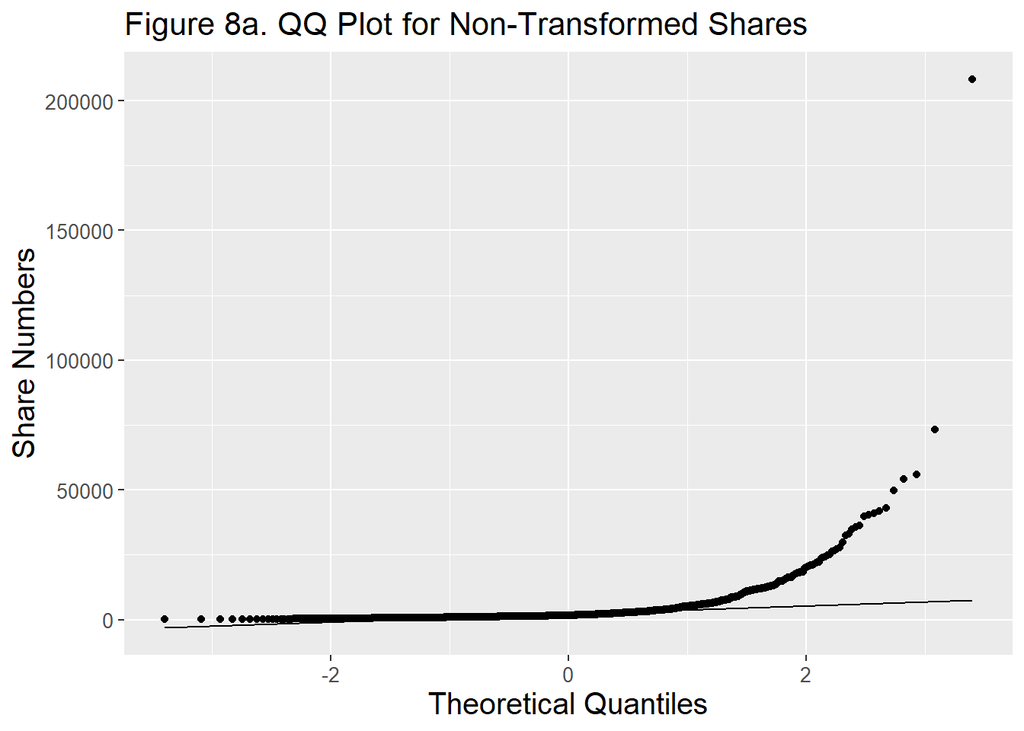

```r
ggplot(edadata) + geom_qq(aes(sample = shares)) + geom_qq_line(aes(sample = shares)) +
  labs(x = "Theoretical Quantiles", y = "Share Numbers",
       title = "Figure 8a. QQ Plot for Non-Transformed Shares") +
    theme(axis.text.x = element_text(size = 10),
        axis.text.y = element_text(size = 10),
        axis.title.x = element_text(size = 15),
        axis.title.y = element_text(size = 15),
        legend.key.size = unit(1, 'cm'),
        legend.text = element_text(size = 13),
        title = element_text(size = 13))
```

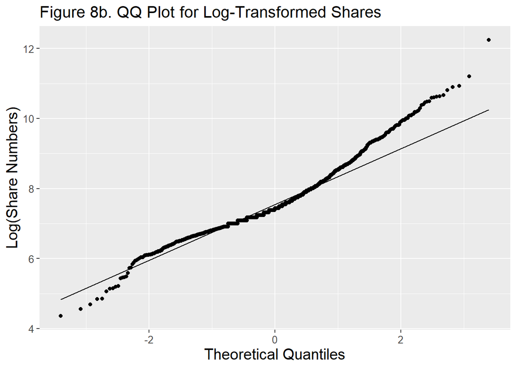

```r
ggplot(edadata) + geom_qq(aes(sample = log(shares))) + geom_qq_line(aes(sample = log(shares))) +
    labs(x = "Theoretical Quantiles", y = "Log(Share Numbers)",
       title = "Figure 8b. QQ Plot for Log-Transformed Shares") +
    theme(axis.text.x = element_text(size = 10),
        axis.text.y = element_text(size = 10),
        axis.title.x = element_text(size = 15),
        axis.title.y = element_text(size = 15),
        legend.key.size = unit(1, 'cm'),
        legend.text = element_text(size = 13),
        title = element_text(size = 13))
```

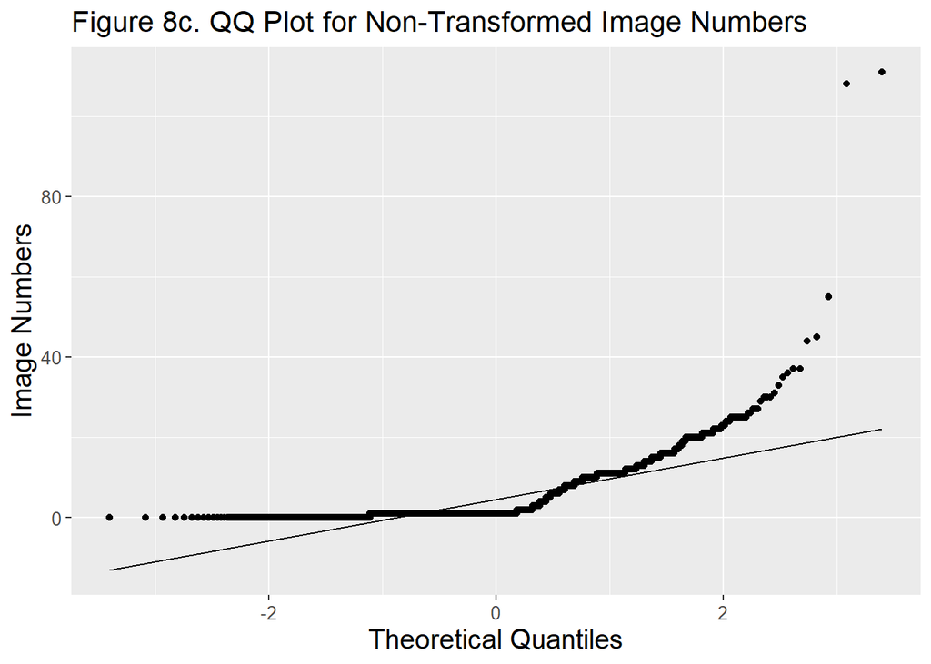

```r
ggplot(edadata) + geom_qq(aes(sample = num_imgs)) + geom_qq_line(aes(sample = num_imgs)) +
  labs(x = "Theoretical Quantiles", y = "Image Numbers",
       title = "Figure 8c. QQ Plot for Non-Transformed Image Numbers") +
    theme(axis.text.x = element_text(size = 10),
        axis.text.y = element_text(size = 10),
        axis.title.x = element_text(size = 15),
        axis.title.y = element_text(size = 15),
        legend.key.size = unit(1, 'cm'),
        legend.text = element_text(size = 13),
        title = element_text(size = 13))
```

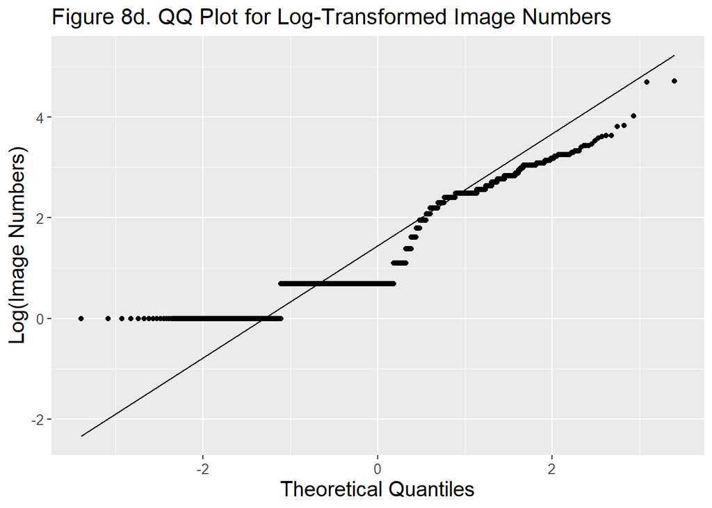

```r
ggplot(edadata) + geom_qq(aes(sample = log(num_imgs + 1))) + geom_qq_line(aes(sample = log(num_imgs + 1))) +
    labs(x = "Theoretical Quantiles", y = "Log(Image Numbers)",
       title = "Figure 8d. QQ Plot for Log-Transformed Image Numbers") +
    theme(axis.text.x = element_text(size = 10),
        axis.text.y = element_text(size = 10),
        axis.title.x = element_text(size = 15),
        axis.title.y = element_text(size = 15),
        legend.key.size = unit(1, 'cm'),
        legend.text = element_text(size = 13),
        title = element_text(size = 13))
```

Whether it’s appropriate to perform a logarithmic transformation on the number of images is somewhat less clear than for the number of shares.

# Candidate Models

## Linear Regression

The linear regression process takes a matrix of all of the predictor variables we’ve chosen and compares their values to each of the corresponding values of the response variable, `log.shares`. This allows us to calculate the most accurate linear combination of the predictor variables to make up the response variable. We can choose a variety of sets of predictors and compare their Root Mean Square Errors, R-Squared values, and Mean Absolute Errors to see which one is the strongest model. Below, we’ve fit multiple linear models that include all of our variables and various combinations of interaction terms and/or quadratic terms.

Originally, we used 20 top ranked predictors selected by the optimal predictive model used in the paper and fit them in three types of models below.

1. All predictors
2. All predictors and their quadratic terms
3. All predictors and all their interaction terms

We repeated this process to trim down the number of predictors and eventually selected the ones that seem to be important in predicting the number of shares, and they are not highly correlated with each other. The parameters in the linear regression model 1 were chosen through this process, and they are listed in Table 8 below. The response variable is `log(shares)`.

The second linear regression model provided below applies a log transformation to the variables `num_imgs` and `self_reference_avg_sharess`, which are extremely skewed to the right even after standardization, to see if this accounts for the outliers in the data and puts those variables in an appropriate context.

Table 8. The predictors in linear regression model 1

| Index | Predictor in Linear Regression 1 | Predictor Information |
| --- | --- | --- |
| 1 | `kw_avg_avg` | Average keyword (average shares) |
| 2 | `LDA_02` | Closeness of current article to a LDA Topic 2 |
| 3 | `dayweek` | Day of a week the article was published |
| 4 | `self_reference_avg_sharess` | Average shares of earlier popularity news referenced in the article |
| 5 | `average_token_length` | Average length of the words in the content |
| 6 | `n_tokens_content` | Number of words in the content |
| 7 | `n_tokens_title` | Number of words in the title |
| 8 | `global_subjectivity` | Text subjectivity |
| 9 | `num_imgs` | Number of images |
| 10 | `I(n_tokens_content^2)` | Quadratic term of number of words in the content |
| 11 | `kw_avg_avg:num_imgs` | Interaction term |
| 12 | `average_token_length:global_subjectivity` | Interaction term |
| 13 | `dayweek:self_reference_avg_sharess` | Interaction term |

We standardized both the training set and the test set before we fit the linear regression models. We used the standardized mean and standard deviation values from the training set on the test set so that the predictors on both sets have the same means and standard deviations. Standardizing the variables is very important prior to model fitting so that all the variables are on the same scale. The variables with large values do not look more important than the variables with smaller values. Especially in our data set where some variable values are unbounded, skewed to one side, and some variables are ratios between 0 and 1.

```r
#train1$dayweek <- as.factor(train1$dayweek)
#test1$dayweek <- as.factor(test1$dayweek)
train1$dayweek <- cut(train1$dayweek, 7, c("Monday", "Tuesday", "Wednesday", "Thursday", "Friday", "Saturday", "Sunday"))
test1$dayweek <- cut(test1$dayweek, 7, c("Monday", "Tuesday", "Wednesday", "Thursday", "Friday", "Saturday", "Sunday"))
preProcValues <- preProcess(train1, method = c("center", "scale"))
trainTransformed1 <- predict(preProcValues, train1)
testTransformed1 <- predict(preProcValues, test1)
trainTransformed1
```

```
## # A tibble: 1,472 x 10
##    log.shares dayweek   kw_avg_avg LDA_02 self_reference_avg_~ average_token_le~
##         <dbl> <fct>          <dbl>  <dbl>                <dbl>             <dbl>
##  1    -1.37   Monday         -2.56 -0.522            -0.186               0.116
##  2    -0.0588 Monday         -2.56 -0.441            -0.378               0.122
##  3     1.11   Monday         -2.56 -0.396            -0.0730              0.477
##  4    -1.56   Monday         -2.56 -0.522            -0.378              -0.400
##  5     0.621  Monday         -2.56 -0.474            -0.378               0.149
##  6    -1.88   Monday         -2.56 -0.517             0.000276           -0.403
##  7    -1.46   Monday         -2.56 -0.475            -0.186               0.0511
##  8    -1.37   Monday         -2.56  1.88             -0.378               0.600
##  9    -0.548  Tuesday        -1.89  0.420            -0.299               0.932
## 10    -0.0588 Wednesday      -1.65 -0.397             0.336              -0.0792
## # ... with 1,462 more rows, and 4 more variables: n_tokens_content <dbl>,
## #   n_tokens_title <dbl>, global_subjectivity <dbl>, num_imgs <dbl>
```

```r
cv_fit1 <- train(log.shares ~ . + I(n_tokens_content^2) + kw_avg_avg:num_imgs +
                   average_token_length:global_subjectivity + dayweek:self_reference_avg_sharess,
                 data=trainTransformed1,
                 method = "lm",
                 trControl = trainControl(method = "cv", number = 10))
summary(cv_fit1)
```

```
##
## Call:
## lm(formula = .outcome ~ ., data = dat)
##
## Residuals:
##     Min      1Q  Median      3Q     Max
## -3.3175 -0.6352 -0.1953  0.4938  4.6046
##
## Coefficients:
##                                                 Estimate Std. Error t value
## (Intercept)                                   -0.0191608  0.0658291  -0.291
## dayweekTuesday                                -0.0818826  0.0910686  -0.899
## dayweekWednesday                              -0.1133024  0.0878858  -1.289
## dayweekThursday                                0.0002381  0.0892309   0.003
## dayweekFriday                                 -0.0870931  0.0932195  -0.934
## dayweekSaturday                                0.2586752  0.1128843   2.292
## dayweekSunday                                  0.1221937  0.1014374   1.205
## kw_avg_avg                                     0.0906101  0.0287118   3.156
## LDA_02                                        -0.0265484  0.0262063  -1.013
## self_reference_avg_sharess                     0.2936412  0.1022398   2.872
## average_token_length                           0.0391978  0.0502118   0.781
## n_tokens_content                               0.0936724  0.0370860   2.526
## n_tokens_title                                 0.0209063  0.0255567   0.818
## global_subjectivity                           -0.0015538  0.0304201  -0.051
## num_imgs                                       0.0290591  0.0326464   0.890
## `I(n_tokens_content^2)`                       -0.0102938  0.0047079  -2.186
## `kw_avg_avg:num_imgs`                          0.1171510  0.0260389   4.499
## `average_token_length:global_subjectivity`     0.0234899  0.0124507   1.887
## `dayweekTuesday:self_reference_avg_sharess`   -0.2292420  0.1565084  -1.465
## `dayweekWednesday:self_reference_avg_sharess` -0.2949869  0.1082046  -2.726
## `dayweekThursday:self_reference_avg_sharess`  -0.2563741  0.1251963  -2.048
## `dayweekFriday:self_reference_avg_sharess`    -0.1518996  0.1361101  -1.116
## `dayweekSaturday:self_reference_avg_sharess`  -0.1499298  0.2129948  -0.704
## `dayweekSunday:self_reference_avg_sharess`    -0.2842474  0.1194082  -2.380
##                                               Pr(>|t|)
## (Intercept)                                    0.77104
## dayweekTuesday                                 0.36873
## dayweekWednesday                               0.19753
## dayweekThursday                                0.99787
## dayweekFriday                                  0.35032
```

[output cut: 10 more lines]

```
## `I(n_tokens_content^2)`                        0.02894 *
## `kw_avg_avg:num_imgs`                         7.37e-06 ***
## `average_token_length:global_subjectivity`     0.05941 .
## `dayweekTuesday:self_reference_avg_sharess`    0.14321
## `dayweekWednesday:self_reference_avg_sharess`  0.00648 **
## `dayweekThursday:self_reference_avg_sharess`   0.04076 *
## `dayweekFriday:self_reference_avg_sharess`     0.26461
## `dayweekSaturday:self_reference_avg_sharess`   0.48160
## `dayweekSunday:self_reference_avg_sharess`     0.01742 *
## ---
## Signif. codes:  0 '***' 0.001 '**' 0.01 '*' 0.05 '.' 0.1 ' ' 1
##
## Residual standard error: 0.9669 on 1448 degrees of freedom
## Multiple R-squared:  0.07975,    Adjusted R-squared:  0.06513
## F-statistic: 5.456 on 23 and 1448 DF,  p-value: 2.518e-15
```

```r
cv_fit2 <- train(log.shares ~ . - num_imgs - self_reference_avg_sharess + I(log(num_imgs+1)) + I(n_tokens_content^2) +
                 I(log(self_reference_avg_sharess+1)) + kw_avg_avg:I(log(num_imgs + 1)) +
                 average_token_length:global_subjectivity,
                 data=trainTransformed1,
                 method = "lm",
                 trControl = trainControl(method = "cv", number = 10))
summary(cv_fit2)
```

```
##
## Call:
## lm(formula = .outcome ~ ., data = dat)
##
## Residuals:
##     Min      1Q  Median      3Q     Max
## -3.2559 -0.6385 -0.1935  0.4877  4.5260
##
## Coefficients:
##                                              Estimate Std. Error t value
## (Intercept)                                 0.0002400  0.0672616   0.004
## dayweekTuesday                             -0.0759217  0.0908469  -0.836
## dayweekWednesday                           -0.1120316  0.0879792  -1.273
## dayweekThursday                             0.0039863  0.0893630   0.045
## dayweekFriday                              -0.0886116  0.0933093  -0.950
## dayweekSaturday                             0.2528487  0.1125150   2.247
## dayweekSunday                               0.1276618  0.1015658   1.257
## kw_avg_avg                                  0.1264231  0.0278104   4.546
## LDA_02                                     -0.0280738  0.0261918  -1.072
## average_token_length                        0.0446570  0.0497141   0.898
## n_tokens_content                            0.0965929  0.0376898   2.563
## n_tokens_title                              0.0209927  0.0255672   0.821
## global_subjectivity                        -0.0001502  0.0305780  -0.005
## `I(log(num_imgs + 1))`                      0.0303453  0.0426734   0.711
## `I(n_tokens_content^2)`                    -0.0069424  0.0045934  -1.511
## `I(log(self_reference_avg_sharess + 1))`    0.1520836  0.0628052   2.422
## `kw_avg_avg:I(log(num_imgs + 1))`           0.1539667  0.0340307   4.524
## `average_token_length:global_subjectivity`  0.0261706  0.0123421   2.120
##                                            Pr(>|t|)
## (Intercept)                                  0.9972
## dayweekTuesday                               0.4035
## dayweekWednesday                             0.2031
## dayweekThursday                              0.9644
## dayweekFriday                                0.3424
## dayweekSaturday                              0.0248 *
## dayweekSunday                                0.2090
## kw_avg_avg                                 5.92e-06 ***
## LDA_02                                       0.2840
## average_token_length                         0.3692
## n_tokens_content                             0.0105 *
## n_tokens_title                               0.4117
## global_subjectivity                          0.9961
## `I(log(num_imgs + 1))`                       0.4771
## `I(n_tokens_content^2)`                      0.1309
## `I(log(self_reference_avg_sharess + 1))`     0.0156 *
## `kw_avg_avg:I(log(num_imgs + 1))`          6.55e-06 ***
## `average_token_length:global_subjectivity`   0.0341 *
## ---
## Signif. codes:  0 '***' 0.001 '**' 0.01 '*' 0.05 '.' 0.1 ' ' 1
##
## Residual standard error: 0.9674 on 1454 degrees of freedom
## Multiple R-squared:  0.07499,    Adjusted R-squared:  0.06417
## F-statistic: 6.934 on 17 and 1454 DF,  p-value: < 2.2e-16
```

```r
pred1 <- predict(cv_fit1, newdata = testTransformed1)
pred2 <- predict(cv_fit2, newdata = testTransformed1)
cv_rmse1 <- postResample(pred1, obs = testTransformed1$log.shares)
cv_rmse2 <- postResample(pred2, obs = testTransformed1$log.shares)
```

## Random Forest

The bootstrap approach to fitting a tree model involves resampling our data and fitting a tree to each sample, and then averaging the resulting predictions of each of those models. The random forest approach adds an extra step for each of these samples, where only a random subset of the predictor variables is chosen each time, in order to reduce the correlation between each of the trees. We don’t have to worry about creating dummy variables for categorical variables, because our data already comes in an entirely numeric form.

Again, we standardized both the training set and the test set before we fit the each of the ensemble models. We used the standardized mean and standard deviation values of the predictors from the training set on the test set so that the predictors on both sets have the same means and standard deviations.

```r
train2 <- train %>% select(-class_shares, -shares, -dayweek, -LDA_00, -LDA_01, -LDA_03, -LDA_04)
test2 <- test %>% select(-class_shares, -shares, -dayweek, -LDA_00, -LDA_01, -LDA_03, -LDA_04)
preProcValues2 <- preProcess(train2, method = c("center", "scale"))
trainTransformed2 <- predict(preProcValues2, train2)
testTransformed2 <- predict(preProcValues2, test2)
trainTransformed2
```

```
## # A tibble: 1,472 x 16
##    log.shares kw_avg_avg LDA_02 weekday_is_monday weekday_is_tuesday
##         <dbl>      <dbl>  <dbl>             <dbl>              <dbl>
##  1    -1.37        -2.56 -0.522             2.37              -0.436
##  2    -0.0588      -2.56 -0.441             2.37              -0.436
##  3     1.11        -2.56 -0.396             2.37              -0.436
##  4    -1.56        -2.56 -0.522             2.37              -0.436
##  5     0.621       -2.56 -0.474             2.37              -0.436
##  6    -1.88        -2.56 -0.517             2.37              -0.436
##  7    -1.46        -2.56 -0.475             2.37              -0.436
##  8    -1.37        -2.56  1.88              2.37              -0.436
##  9    -0.548       -1.89  0.420            -0.422              2.29
## 10    -0.0588      -1.65 -0.397            -0.422             -0.436
## # ... with 1,462 more rows, and 11 more variables: weekday_is_wednesday <dbl>,
## #   weekday_is_thursday <dbl>, weekday_is_friday <dbl>,
## #   weekday_is_saturday <dbl>, weekday_is_sunday <dbl>,
## #   self_reference_avg_sharess <dbl>, average_token_length <dbl>,
## #   n_tokens_content <dbl>, n_tokens_title <dbl>, global_subjectivity <dbl>,
## #   num_imgs <dbl>
```

```r
random_forest <- train(log.shares ~ ., data = trainTransformed2,
    method = "rf",
    trControl = trainControl(method = "cv", number = 5),
    tuneGrid = data.frame(mtry = 1:5), importance = TRUE)

random_forest_predict <- predict(random_forest, newdata = testTransformed2)
rf_rmse <- postResample(random_forest_predict, obs = testTransformed2$log.shares)
random_forest
```

```
## Random Forest
##
## 1472 samples
##   15 predictor
##
## No pre-processing
## Resampling: Cross-Validated (5 fold)
## Summary of sample sizes: 1179, 1177, 1179, 1177, 1176
## Resampling results across tuning parameters:
##
##   mtry  RMSE       Rsquared    MAE
##   1     0.9797739  0.04972620  0.7516122
##   2     0.9800207  0.04379828  0.7527251
##   3     0.9804460  0.04572803  0.7532795
##   4     0.9806098  0.04682730  0.7536991
##   5     0.9836604  0.04383146  0.7568901
##
## RMSE was used to select the optimal model using the smallest value.
## The final value used for the model was mtry = 1.
```

```r
random_forest$results
```

```
##   mtry      RMSE   Rsquared       MAE     RMSESD RsquaredSD      MAESD
## 1    1 0.9797739 0.04972620 0.7516122 0.04102333 0.02397952 0.02632816
## 2    2 0.9800207 0.04379828 0.7527251 0.04584915 0.02460272 0.02753385
## 3    3 0.9804460 0.04572803 0.7532795 0.04583086 0.02506405 0.02636886
## 4    4 0.9806098 0.04682730 0.7536991 0.04822374 0.02320305 0.02753557
## 5    5 0.9836604 0.04383146 0.7568901 0.04990236 0.02322215 0.02840284
```

```r
# mtry = random_forest$bestTune[[1]]
```

We then used 5 fold cross validation to search for the tuning parameter value ranging from 1 to 5 that produces the optimal random forest model. The optimal model chosen by cross validation produced the smallest RMSE value when mtry = 1 and the lowest RMSE = 0.9797739 when training the model on the training set.

## Boosted Tree

There are tuning parameters in gradient boosting machine learning technique to help us prevent from growing the trees too quickly and thus keep us from overfitting the model.

- `shrinkage`: A shrinkage parameter controls the growth rate of the trees, slows fitting process
- `n.trees`: The amount of times we want to the process to repeat in training the trees.
- `interaction.depth`: The amount of splits we want to fit a tree.
- `n.minobsinnode`: The minimum number of observations in a node at least.

Here, we use the `caret` package and the `gbm` package to run the boosted tree model with the training set and predict on the test set. The values of the tuning parameters are set as below:

- `shrinkage` = 0.1
- `n.trees` = 25, 50, 75, 100, 125
- `interaction.depth` = 1, 2, 3, 4, 5
- `n.minobsinnode` = 10

We then used 10 fold cross validation to search all combinations of the tuning parameters values using the `expand.grid` function to choose an optimal model with the desired tuning parameters values. The optimal model chosen by cross validation across all combinations of tuning parameters values produces the lowest root mean squared error (RMSE).

```r
#expand.grid(n.trees = c(25, 50, 75, 100, 125), interaction.depth = 1:5, shrinkage = 0.1, n.minobsinnode = 10)
boosted_tree <- train(log.shares ~ . , data = trainTransformed2,
      method = "gbm",
      trControl = trainControl(method = "cv", number = 10), #method="repeatedcv", repeats=5
      tuneGrid = expand.grid(n.trees = c(25, 50, 75, 100, 125), interaction.depth = 1:5, shrinkage = 0.1, n.minobsinnode = 10),
      verbose = FALSE)
boosted_tree_predict <- predict(boosted_tree, newdata = select(testTransformed2, -log.shares))
boost_rmse <- postResample(boosted_tree_predict, obs = testTransformed2$log.shares)
boosted_tree
```

```
## Stochastic Gradient Boosting
##
## 1472 samples
##   15 predictor
##
## No pre-processing
## Resampling: Cross-Validated (10 fold)
## Summary of sample sizes: 1325, 1326, 1325, 1325, 1324, 1325, ...
## Resampling results across tuning parameters:
##
##   interaction.depth  n.trees  RMSE       Rsquared    MAE
##   1                   25      0.9769836  0.04770778  0.7494999
##   1                   50      0.9776899  0.04358768  0.7488421
##   1                   75      0.9795196  0.04119715  0.7507544
##   1                  100      0.9797796  0.04168059  0.7496812
##   1                  125      0.9829633  0.03768929  0.7525519
##   2                   25      0.9749324  0.04846097  0.7486882
##   2                   50      0.9818082  0.03866540  0.7511064
##   2                   75      0.9849727  0.03717623  0.7522272
##   2                  100      0.9889651  0.03357259  0.7534582
##   2                  125      0.9902417  0.03380704  0.7544737
##   3                   25      0.9803310  0.03904670  0.7499339
##   3                   50      0.9880751  0.03251430  0.7537922
##   3                   75      0.9914815  0.03157919  0.7560888
##   3                  100      0.9972540  0.02750305  0.7617255
##   3                  125      1.0002613  0.02766825  0.7643401
##   4                   25      0.9832446  0.03685641  0.7519685
##   4                   50      0.9913671  0.03188742  0.7581352
##   4                   75      1.0022470  0.02307663  0.7678374
##   4                  100      1.0124373  0.01825297  0.7760306
##   4                  125      1.0191248  0.01701350  0.7813262
##   5                   25      0.9771076  0.04487131  0.7472190
##   5                   50      0.9847193  0.03823500  0.7529846
##   5                   75      0.9932727  0.03219481  0.7574308
##   5                  100      1.0001856  0.02953811  0.7654409
##   5                  125      1.0083956  0.02605447  0.7714343
##
## Tuning parameter 'shrinkage' was held constant at a value of 0.1
##
## Tuning parameter 'n.minobsinnode' was held constant at a value of 10
## RMSE was used to select the optimal model using the smallest value.
## The final values used for the model were n.trees = 25, interaction.depth =
##  2, shrinkage = 0.1 and n.minobsinnode = 10.
```

```r
#boosted_tree$results
# n.trees = boosted_tree$bestTune[[1]]
```

We then used 10 fold cross validation to search all combinations of the tuning parameters values using the `expand.grid` function to choose an optimal model with the desired tuning parameters values. The optimal boosted tree model chosen by cross validation produced the smallest RMSE value (0.9749324) when n.trees = 25, interaction.depth = 2, shrinkage = 0.1 and n.minobsinnode = 10 when training the model with the training set.

## Model Comparisons

The best model fit to predict the number of shares for the lifestyle channel can be determined by looking at the Root Mean Squared Error, the Mean Absolute Error, or the R-squared value using the test set. Table 8 shows these criteria measures for each candidate model. The approach I’ve taken below picks whichever model is considered superior by the majority score of these three metrics, and if each of the metrics picks a different model or the majority score is a tiebreaker, then the one with the lowest RMSE will be chosen.

```r
result2 <- rbind(cv_rmse1, cv_rmse1, rf_rmse, boost_rmse)
row.names(result2) <- c("Linear Regression 1", "Linear Regression 2", "Random Forest", "Boosted Tree")
kable(result2, digits = 4, caption = "Table 8. Cross Validation - Comparisons of the models in test set")
```

Table 8. Cross Validation - Comparisons of the models in test set

[output not shown]

```r
rmse_best <- names(which.min(result2[,1]))
rsq_best <- names(which.max(result2[,2]))
mae_best <- names(which.min(result2[,3]))
model_best <- table(c(rmse_best, rsq_best, mae_best))
final_model <- if_else(max(model_best) > 1, names(which.max(model_best)), rmse_best)
```

We built a helper function so that when a final winning model is declared among the candidate models using the test set, we then used the final model to fit the entire data set, both the training and the test sets, from the lifestyle channel. A variable importance plot is produced along with a table containing a ranking metrics of the variable importance when fitting the final model with the entire data set of the lifestyle articles.

```r
linear1 <- function(...){

  data1comb <- rbind(trainTransformed1, testTransformed1, ...)
  linearfit1 <- train(log.shares ~ . + I(n_tokens_content^2) + kw_avg_avg:num_imgs +
                        average_token_length:global_subjectivity + dayweek:self_reference_avg_sharess,
                      data=data1comb,
                      method = "lm", ...)
  pred <- predict(linearfit1, newdata = data1comb, ...)
  linear.rmse <- postResample(pred, obs = data1comb$log.shares, ...)
  #colnames(linear.rmse) <- "Linear Regression 1"
  linear_rmse <- kable(linear.rmse, digits = 4, caption = "10. Final model fit on entire data", ...)
  summary <- summary(linearfit1)
  important <- varImp(linearfit1, ...)
  plot_imp <- vip(linearfit1, ...)
  return(list(linear_rmse, summary, important, plot_imp))

}

linear2 <- function(...){

  data1comb <- rbind(trainTransformed1, testTransformed1, ...)
  linearfit2 <- train(log.shares ~ . - num_imgs - self_reference_avg_sharess + I(n_tokens_content^2) +
                        I(log(num_imgs + 1)) + I(log(self_reference_avg_sharess+1)) +
                        kw_avg_avg:I(log(num_imgs + 1)) + average_token_length:global_subjectivity,
                      data=data1comb,
                      method = "lm", ...)
  pred <- predict(linearfit2, newdata = data1comb, ...)
  linear.rmse <- postResample(pred, obs = data1comb$log.shares, ...)
  #row.names(linear.rmse) <- "Linear Regression 2"
  linear_rmse <- kable(linear.rmse, digits = 4, caption = "10. Final model fit on entire data", ...)
  summary <- summary(linearfit2)
  return(list(linear_rmse, summary, important, plot_imp))

}

randomf <- function(...){

  data2comb <- rbind(trainTransformed2, testTransformed2, ...)
  rffit <- train(log.shares ~ . , data = data2comb,
                 method = "rf",
                 tuneGrid = data.frame(mtry = random_forest$bestTune[[1]]),
                 importance = TRUE, ...)
  important <- varImp(rffit , ...)
  plot_imp <- vip(rffit, ...)
  return(list(rffit, important, plot_imp))

}

boostedt <- function(...){

  data2comb <- rbind(trainTransformed2, testTransformed2, ...)
  btfit <- train(log.shares ~ . , data = data2comb,
                 method = "gbm",
                 tuneGrid = data.frame(n.trees = boosted_tree$bestTune[[1]],
                                       interaction.depth = boosted_tree$bestTune[[2]],
                                       shrinkage = boosted_tree$bestTune[[3]],
                                       n.minobsinnode = boosted_tree$bestTune[[4]]),
                 verbose = FALSE, ...)
  important <- varImp(btfit, ...)
  plot_imp <- vip(btfit, ...)
  return(list(btfit, important, plot_imp))

}
```

# Final Model Fit with Entire Data

The best model fit to predict the number of shares is the **Random Forest** model for the lifestyle articles. We fit the entire data set, both the training and the test set from the channel in the final chosen model. The values of RMSE, MAE and R-squared are calculated with the entire data set using the final model. A variable importance plot of the top 10 most important variables and a table containing a ranking metric of the relative variable importance are produced below. We can examine which predictors contributed the most in predicting the popularity of online news in the final model accordingly. Table 1 containing attribute information from the *Introduction* section is copied below for comparisons of variable importance.

Table 1. Attributes used in the analyses for prediction of online news popularity

| Index | Attribute | Attribute Information | Type |
| --- | --- | --- | --- |
| 1 | `shares` (target) | Number of shares | number |
| 2 | `kw_avg_avg` | Average keyword (average shares) | number |
| 3 | `LDA_02` | Closeness of current article to a LDA Topic 2 | ratio |
| 4.1 | `weekday_is_monday` | Was the article published on a Monday? | boolean |
| 4.2 | `weekday_is_tuesday` | Was the article published on a Tuesday? | boolean |
| 4.3 | `weekday_is_wednesday` | Was the article published on a Wednesday? | boolean |
| 4.4 | `weekday_is_thursday` | Was the article published on a Thursday? | boolean |
| 4.5 | `weekday_is_friday` | Was the article published on a Friday? | boolean |
| 4.6 | `weekday_is_saturday` | Was the article published on a Saturday? | boolean |
| 4.7 | `weekday_is_sunday` | Was the article published on a Sunday? | boolean |
| 5 | `self_reference_avg_sharess` | Avg. shares of popular news referenced in the articles | number |
| 6 | `average_token_length` | Average length of the words in the content | number |
| 7 | `n_tokens_content` | Number of words in the content | number |
| 8 | `n_tokens_title` | Number of words in the title | number |
| 9 | `global_subjectivity` | Text subjectivity | ratio |
| 10 | `num_imgs` | Number of images | number |

```r
f_model <- if_else(final_model == "Random Forest", 3,
           if_else(final_model == "Boosted Tree", 4,
                   if_else(final_model == "Linear Regression 1", 1, 2)))

switch(f_model,

       modell = linear1(),
       model2 = linear2(),
       model3 = randomf(),
       model4 = boostedt()
)
```

```
## [[1]]
## Random Forest
##
## 2099 samples
##   15 predictor
##
## No pre-processing
## Resampling: Bootstrapped (25 reps)
## Summary of sample sizes: 2099, 2099, 2099, 2099, 2099, 2099, ...
## Resampling results:
##
##   RMSE       Rsquared    MAE
##   0.9841459  0.05295993  0.7501863
##
## Tuning parameter 'mtry' was held constant at a value of 1
##
## [[2]]
## rf variable importance
##
##                            Overall
## kw_avg_avg                 100.000
## num_imgs                    96.939
## weekday_is_saturday         96.333
## self_reference_avg_sharess  78.312
## weekday_is_sunday           74.758
## n_tokens_content            68.328
## average_token_length        57.266
## global_subjectivity         53.275
## weekday_is_wednesday        46.169
## LDA_02                      26.641
## weekday_is_tuesday          18.847
## weekday_is_friday           17.004
## weekday_is_thursday         13.297
## n_tokens_title               8.667
## weekday_is_monday            0.000
##
## [[3]]
```

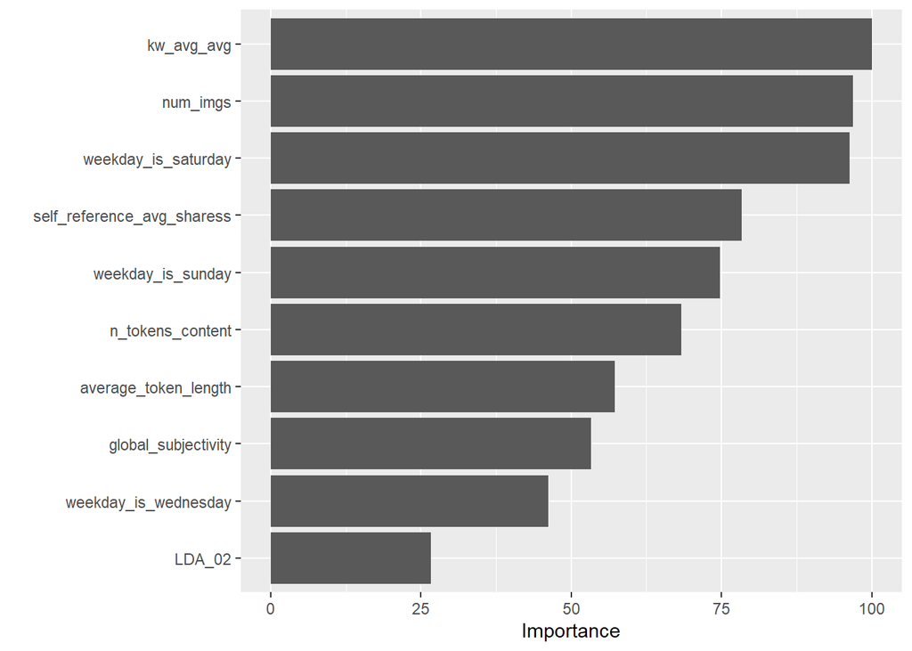

```r
#imp <- varImp(boosted_tree)
#imp2 <- data.frame(imp[1])
#first <- rownames(imp2)[order(imp2$Overall, decreasing=TRUE)][1] # most important
#second <- rownames(imp2)[order(imp2$Overall, decreasing=TRUE)][2] #2nd
#third <- rownames(imp2)[order(imp2$Overall, decreasing=TRUE)][3] # 3rd
#print(paste0("The most important predictor is ", first, ", the second is ", second))
```

# Automation

To knit with the parameters with this single .Rmd file, we specified the parameters in the YAML header and created a data frame which contains both the output .md file names and the parameters we supplied to the YAML header to automate the reports. Both the names of the parameters and the values of the parameters were saved in a list format in that data frame. Then, we used the render function below to knit with the parameters in R console to generate the reports. The render function is not evaluated with this .Rmd file.

```r
type <- c("lifestyle", "entertainment", "bus", "socmed", "tech", "world")
output_file <- paste0(type, ".md")
params <- lapply(type, FUN = function(x){list(channel = x)})
reports <- tibble(output_file, params)

apply(reports, MARGIN = 1,
      FUN = function(x){
        render(input = "C:/Users/peach/Documents/ST558/ST558_repos/ST558-Project-2/_Rmd/ST558_project2_auto.Rmd",
               output_format = "github_document",
               output_file = paste0("C:/Users/peach/documents/ST558/ST558_repos/ST558-Project-2/", x[[1]]),
               params = x[[2]],
               output_options = list(html_preview = FALSE, toc = TRUE, toc_depth = 3, df_print = "tibble"))
      })
```